# k8s元件

# kubernetes架構

**Kubernetes採用主從分布式架構:**

**Kubernetes 四元件**

- Master Nodes
- Worker Node
- Pod
- Cluster

節點

**Master Node - 管理節點**

扮演著管理叢集的角色，可透過CLI、APIs、Dashboard等控制介面與 Master 溝通進而存取、控制或修改叢集狀態，此外，k8s 利用 etcd 來儲存叢集的狀態。而 Master 會透過 etcd 了解目前叢集的運行狀況。

- API Server - k8s平台API⼊⼝, 處理REST操作及更新etcd中的對象(資源物件)
- 調度器(Scheduler) - 資源調度, 將Pod綁定到某個節點上
- 控制器(Controller Manager) - ⾃動化控制中⼼
- etcd資料庫 -永久性狀態資訊儲存所在的資料庫

**Worker Node - ⼯作(計算)節點**

- kubelet - 管理Pod、容器、映像檔、儲存卷(Volume)等, 針對節點管理
- kube-proxy - 提供網路代理、負載平衡以及Service通訊
- Docker Engine - 負責節點的容器管理⼯作

**Pod**

- Kubernetes 運作的最小單位，一個 Pod 對應到一個應用服務（Application） ，例如一個 Pod 可能會對應到一個 API Server。
  - 一個 Pod 裡面可以有一個或是多個 Container，但一般情況一個 Pod 最好只有一個 Container
  - 同一個 Pod 中的 Containers 共享相同資源及網路，彼此透過 local port number 溝通

**Cluster** - Kubernetes 中多個 Node 與 Master 的集合。

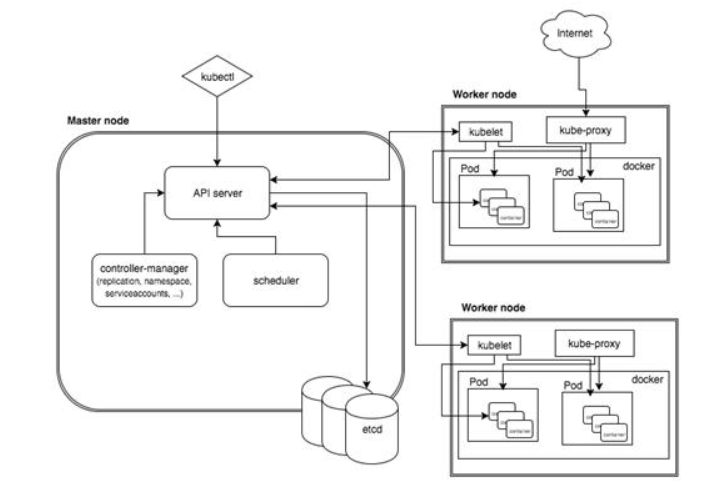

**kubernetes各服務:**

master Node元件

- API Server
  - REST API接⼝ - 包含認証授權, 數據校驗及叢集狀態變更
  - 提供與其它模組之間的數據交互通信的樞扭
    - 各模組透過API Server將訊息寫⼊⾄etcd資料庫
  - API Server儲存數據(只有API Server才能操作etcd), 其它模組透過API Server查詢叢集狀態
- Controller Manager
  - 為叢集內部的⾃動化管理控制中⼼
    - 負責Node, Pod複本, 端點(Endpoint), 命名空間(Namespace), 服務帳號 (ServiceAccount), 資源對象定額(ResourceQuota)的管理與運行
- scheduler
  - scheduler負責資源調度, 在整個叢集中扮演『承上啟下』的功能 -負責接收Controller Manager所建置新Pod的需求, 並於叢集中挑選最適合的節點將其執⾏
    - 節點上的kubelet接管Pod的⽣命週期

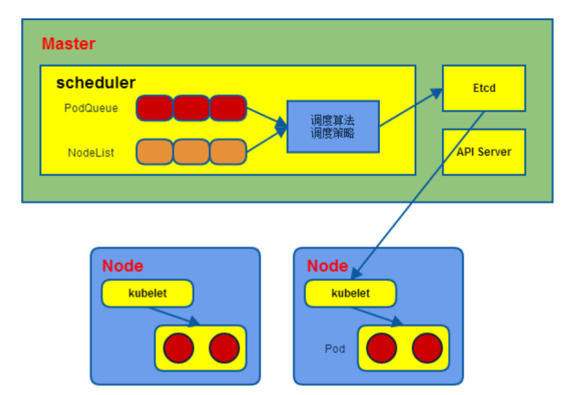

- etcd -⽤於存放叢集內所有資源對象及相關服務的資料,如當Master節點發⽣異常時可透過etcd還原叢集狀態

Worker Node元件

- kubelet
  - 每個宿主機(Worker Node)節點皆會啟動kubelet服務,⽤ 來處理Master節點對各節點所下達的任務
  - 扮演Node管理員的角色，負責管理該 Node 上的所有 Pods 的狀態並負責與 Master 溝通
    - kubetlet於Master節點與API Server互通
      - 定期向Master匯報節點資源使⽤狀況
  - 容器健康檢查
- kube-proxy
  - kube-proxy是為了解決外部網路能夠存取叢集中容器所提供的應⽤服務所設計
  - kube-proxy其實就是管理Service存取的⼊⼝
    - 叢集中的Pod到Service的存取
    - 叢集外客⼾端存取Service
  - kube-proxy管理Service中的服務端點(Endpoints)

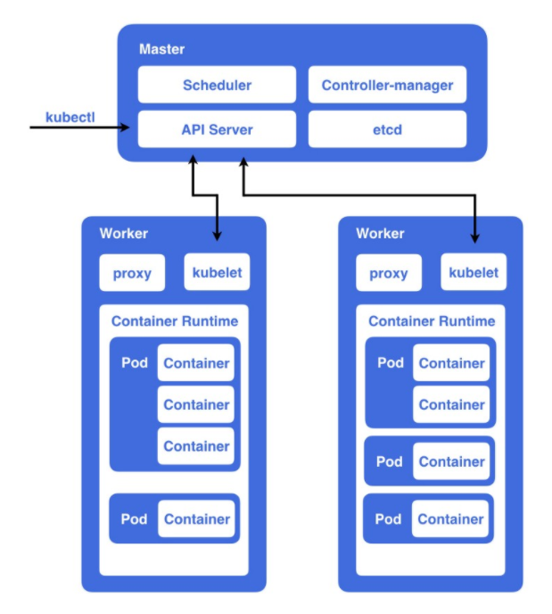